# Introduction

# Data Overview

## The variables

[output not shown]

#### Each item corresponds to a candidate, the attributes of each item are as follows:

- **ano** : Year at which the election took place.
- **sequencial_candidato** : Sequential ID to map the candidates
- **nome** : Name of the candidate
- **uf** : Federate state to which the candidate belongs.
- **partido** : Political party to which the candidate belongs.
- **quantidade_doacoes** : Number of donations received during political campaign.
- **quantidade_doadores** : Number of donors that contributed to the candidate's political campaign.
- **total_receita** : Total revenue.
- **media_receita** : Mean revenue.
- **recursos_de_outros_candidatos.comites** : Revenue from other candidate's committees.
- **recursos_de_pessoas_fisicas** : Revenue from individuals.
- **recursos_de_pessoas_juridicas** : Revenue from legal entities.
- **recursos_proprios** : Revenue from personal resources.
- **recursos_de_partido_politico** : Revenue from political party.
- **quantidade_despesas** : Number of expenses.
- **quantidade_fornecedores** : Number of suppliers.
- **total_despesa** : Total expenditure.
- **media_despesa** : Mean expenditure.
- **cargo** : Position.
- **sexo** : Sex.
- **grau** : Level of education.
- **estado_civil** : Marital status.
- **ocupacao** : Candidate's occupation up to the election.
- **situacao** : Whether the candidate was elected.

## Loading Data

```r
library(dataPreparation)
library(tidyverse)
library(janitor)
library(magrittr)
library(GGally)
library(caret)
library(keras)
library(ROSE)
library(here)

theme_set(theme_bw())
```

```
dataPreparation 0.3.5
✖ lubridate::as.difftime() masks base::as.difftime()






here() starts at /kaggle/working
```

```r
readr::read_csv(here::here('../input/train_class.csv'),
                progress = FALSE,
                local=readr::locale("br"),
                col_types = cols(ano = col_integer(),
                                 sequencial_candidato = col_character(),
                                 quantidade_doacoes = col_integer(),
                                 quantidade_doadores = col_integer(),
                                 total_receita = col_double(),
                                 media_receita = col_double(),
                                 recursos_de_outros_candidatos.comites = col_double(),
                                 recursos_de_pessoas_fisicas = col_double(),
                                 recursos_de_pessoas_juridicas = col_double(),
                                 recursos_proprios = col_double(),
                                 `recursos_de_partido_politico` = col_double(),
                                 quantidade_despesas = col_integer(),
                                 quantidade_fornecedores = col_integer(),
                                 total_despesa = col_double(),
                                 media_despesa = col_double(),
                                 situacao = col_character(),
                                 .default = col_character())) %>%
  mutate(sequencial_candidato = as.numeric(sequencial_candidato),
         estado_civil = as.factor(estado_civil),
         ocupacao = as.factor(ocupacao),
         partido = as.factor(partido),
         cargo = as.factor(cargo),
         nome = as.factor(nome),
         grau = as.factor(grau),
         sexo = as.factor(sexo),
         uf = as.factor(uf)) -> data

data %>%
  glimpse()
```

```
Observations: 7,622
Variables: 24
$ ano                                   <int> 2006, 2006, 2006, 2006, 2006,...
$ sequencial_candidato                  <dbl> 10001, 10002, 10002, 10002, 1...
$ nome                                  <fct> JOSÉ LUIZ NOGUEIRA DE SOUSA, ...
$ uf                                    <fct> AP, RO, AP, MS, RO, AP, PI, M...
$ partido                               <fct> PT, PT, PT, PRONA, PT, PT, PC...
$ quantidade_doacoes                    <int> 6, 13, 17, 6, 48, 8, 6, 14, 2...
$ quantidade_doadores                   <int> 6, 13, 16, 6, 48, 8, 6, 7, 2,...
$ total_receita                         <dbl> 16600.00, 22826.00, 158120.80...
$ media_receita                         <dbl> 2766.67, 1755.85, 9301.22, 50...
$ recursos_de_outros_candidatos.comites <dbl> 0.00, 6625.00, 2250.00, 0.00,...
$ recursos_de_pessoas_fisicas           <dbl> 9000.00, 15000.00, 34150.00, ...
$ recursos_de_pessoas_juridicas         <dbl> 6300.00, 1000.00, 62220.80, 1...
$ recursos_proprios                     <dbl> 1300.00, 201.00, 59500.00, 75...
$ recursos_de_partido_politico          <dbl> 0, 0, 0, 0, 0, 0, 0, 0, 0, 11...
$ quantidade_despesas                   <int> 14, 24, 123, 8, 133, 38, 9, 1...
$ quantidade_fornecedores               <int> 14, 23, 108, 8, 120, 37, 9, 1...
$ total_despesa                         <dbl> 16583.60, 20325.99, 146011.70...
$ media_despesa                         <dbl> 1184.54, 846.92, 1187.09, 375...
$ cargo                                 <fct> DEPUTADO FEDERAL, DEPUTADO FE...
$ sexo                                  <fct> MASCULINO, FEMININO, FEMININO...
$ grau                                  <fct> ENSINO MÉDIO COMPLETO, SUPERI...
$ estado_civil                          <fct> CASADO(A), SOLTEIRO(A), VIÚVO...
$ ocupacao                              <fct> VEREADOR, SERVIDOR PÚBLICO ES...
$ situacao                              <chr> "nao_eleito", "nao_eleito", "...
```

```r
data %>%
  map_df(function(x) sum(is.na(x))) %>%
  gather(feature, num_nulls) %>%
  arrange(desc(num_nulls))
```

| feature | num_nulls |
| --- | --- |
| ano | 0 |
| sequencial_candidato | 0 |
| nome | 0 |
| uf | 0 |
| partido | 0 |
| quantidade_doacoes | 0 |
| quantidade_doadores | 0 |
| total_receita | 0 |
| media_receita | 0 |
| recursos_de_outros_candidatos.comites | 0 |
| recursos_de_pessoas_fisicas | 0 |
| recursos_de_pessoas_juridicas | 0 |
| recursos_proprios | 0 |
| recursos_de_partido_politico | 0 |
| quantidade_despesas | 0 |
| quantidade_fornecedores | 0 |
| total_despesa | 0 |
| media_despesa | 0 |
| cargo | 0 |
| sexo | 0 |
| grau | 0 |
| estado_civil | 0 |
| ocupacao | 0 |
| situacao | 0 |

## Data Exploration

### Imbalance on class distribution

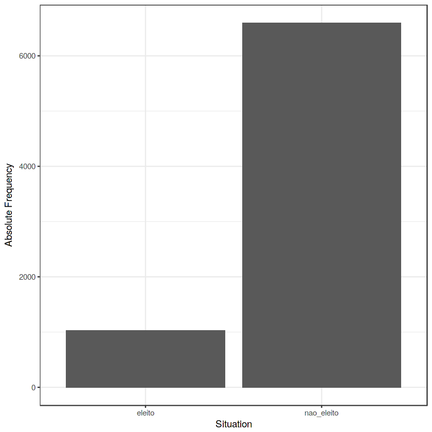

```r
data %>%
  ggplot(aes(situacao)) +
  geom_bar() +
  labs(x="Situation", y="Absolute Frequency")
```

```r
data %>%
  group_by(situacao) %>%
  summarise(num = n()) %>%
  ungroup() %>%
  mutate(total = sum(num),
         proportion = num/total)
```

| situacao | num | total | proportion |
| --- | --- | --- | --- |
| eleito | 1026 | 7622 | 0.1346103 |
| nao_eleito | 6596 | 7622 | 0.8653897 |

#### There's a strong imbalance in the class distribution of the dataset with around 13% of the entries in the class "eleito" (elected).

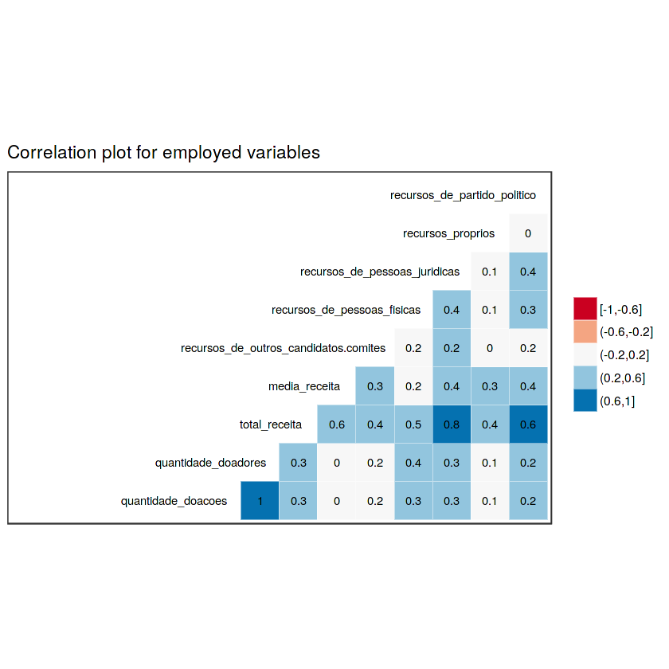

```r
data %>%
  select(-ano,
         -sequencial_candidato,
         -nome) %>%
  select(
    quantidade_doacoes,
    quantidade_doadores,
    total_receita,
    media_receita,
    recursos_de_outros_candidatos.comites,
    recursos_de_pessoas_fisicas,
    recursos_de_pessoas_juridicas,
    recursos_proprios,
    `recursos_de_partido_politico`) %>%
  na.omit() %>%
  ggcorr(palette = "RdBu", label = TRUE,
       hjust = 0.95, label_size = 3,size = 3,
       nbreaks = 5, layout.exp = 5) +
  ggtitle("Correlation plot for employed variables")
```

- Predictors such as quantidade_doacoes (Number of Donations) and quantidade_doadores (Number of Donors) are highly correlated and therefore redundant.

# Preparing data

## Splitting data

```r
set.seed(107)

data$id <- 1:nrow(data)

data %>%
  dplyr::sample_frac(.8) -> train

cat("#### Train Shape",
    "\n##### Observations: ",nrow(train),
    "\n##### Variables: ",ncol(train))
```

```
#### Train Shape
##### Observations:  6098
##### Variables:  25
```

```r
dplyr::anti_join(data,
                 train,
                 by = 'id') -> test

cat("#### Test Shape",
    "\n##### Observations: ",nrow(test),
    "\n##### Variables: ",ncol(test))
```

```
#### Test Shape
##### Observations:  1524
##### Variables:  25
```

```r
train %>%
    select(-ano,-nome,-id,-sequencial_candidato) -> train

test %>%
    select(-ano,-nome,-id,-sequencial_candidato) -> test
```

```r
train %>%
  dplyr::select_if(.,is.numeric) -> train.numeric

train %>%
  dplyr::select_if(.,negate(is.numeric)) -> train.categorical

test %>%
  dplyr::select_if(.,is.numeric) -> test.numeric

test %>%
  dplyr::select_if(.,negate(is.numeric)) -> test.categorical
```

```r
train.numeric %>%
  preProcess(.,method = c("center","scale")) -> processParams

processParams %>%
  predict(.,train.numeric) -> train.numeric

processParams %>%
  predict(.,test.numeric) -> test.numeric

processParams
```

```
Created from 6098 samples and 13 variables

Pre-processing:
  - centered (13)
  - ignored (0)
  - scaled (13)
```

```r
train.numeric %>%
  dplyr::bind_cols(train.categorical) -> train

test.numeric %>%
  dplyr::bind_cols(test.categorical) -> test
```

## Generate Balanced Data with ROSE algorithm

```r
train %>%
clean_names() %>%
ROSE(situacao ~ .,
     data =.,
     seed = 107) %$%
data -> train.rose

cat("#### Train Shape",
    "\n##### Observations: ",nrow(train.rose),
    "\n##### Variables: ",ncol(train.rose))
```

```
#### Train Shape
##### Observations:  6098
##### Variables:  21
```

```r
train.rose %>%
  group_by(situacao) %>%
  summarise(num = n()) %>%
  ungroup() %>%
  mutate(total = sum(num),
         proportion = num/total)
```

| situacao | num | total | proportion |
| --- | --- | --- | --- |
| eleito | 3030 | 6098 | 0.4968842 |
| nao_eleito | 3068 | 6098 | 0.5031158 |

## One hot encoding

```r
encoding <- build_encoding(dataSet = train,
                          cols = c("uf","sexo","grau","ocupacao",
                                   "partido","estado_civil"),
                          verbose = F)

train <- one_hot_encoder(dataSet = train,
                          encoding = encoding,
                          drop = TRUE,
                          verbose = F)

cat("#### Train Shape",
    "\n##### Observations: ",nrow(train),
    "\n##### Variables: ",ncol(train))
```

```
#### Train Shape
##### Observations:  6098
##### Variables:  263
```

```r
train.rose <- one_hot_encoder(dataSet = train.rose,
                              encoding = encoding,
                              drop = TRUE,
                              verbose = F)

cat("#### Balanced Data Shape",
    "\n##### Observations: ",nrow(train.rose),
    "\n##### Variables: ",ncol(train.rose))
```

```
#### Balanced Data Shape
##### Observations:  6098
##### Variables:  263
```

```r
test <- one_hot_encoder(dataSet = test,
                          encoding = encoding,
                          drop = TRUE,
                          verbose = F)

cat("#### Test Data Shape",
    "\n##### Observations: ",nrow(test),
    "\n##### Variables: ",ncol(test))
```

```
#### Test Data Shape
##### Observations:  1524
##### Variables:  263
```

## Near Zero Variance Predictors

```r
train %>%
  nearZeroVar(saveMetrics = TRUE) %>%
  tibble::rownames_to_column("variable") %>%
  filter(nzv == T) %>%
  pull(variable) -> near_zero_vars

train %>%
    select(-one_of(near_zero_vars)) -> train

train.rose %>%
    select(-one_of(near_zero_vars)) -> train.rose

test %>%
    select(-one_of(near_zero_vars)) -> test


near_zero_vars %>%
  glimpse()
```

```
 chr [1:224] "cargo" "uf.AC" "uf.AL" "uf.AM" "uf.AP" "uf.BA" "uf.CE" ...
```

## Conform data to Keras

```r
split_target_predictors <- function(df) {

  df %>%
    select(-situacao) %>%
    as.matrix() -> x_data

  df %>%
    select(situacao) %>%
    dummyVars(" ~ situacao", data = .,levelsOnly = TRUE) -> dmy

  df %>%
    select(situacao) %>%
    data.frame(predict(dmy, newdata = .)) %>%
    select(-situacao) %>%
    as.matrix() -> y_data

  dimnames(x_data) <- NULL
  dimnames(y_data) <- NULL

  newData <- list("predictors" = x_data, "target" = y_data)
  return(newData)
}
```

## Prepare test data

```r
test %>%
   split_target_predictors() -> x_test

# extract target and predictors
y_test <- x_test$target
x_test <- x_test$predictors
```

## Prepare submission data

```r
readr::read_csv(here::here('../input/test_class.csv'),
                progress = FALSE,
                local=readr::locale("br"),
                col_types = cols(ano = col_integer(),
                                 sequencial_candidato = col_character(),
                                 quantidade_doacoes = col_integer(),
                                 quantidade_doadores = col_integer(),
                                 total_receita = col_double(),
                                 media_receita = col_double(),
                                 recursos_de_outros_candidatos.comites = col_double(),
                                 recursos_de_pessoas_fisicas = col_double(),
                                 recursos_de_pessoas_juridicas = col_double(),
                                 recursos_proprios = col_double(),
                                 `recursos_de_partido_politico` = col_double(),
                                 quantidade_despesas = col_integer(),
                                 quantidade_fornecedores = col_integer(),
                                 total_despesa = col_double(),
                                 media_despesa = col_double(),
                                 .default = col_character())) %>%
  mutate(sequencial_candidato = as.numeric(sequencial_candidato),
         estado_civil = as.factor(estado_civil),
         ocupacao = as.factor(ocupacao),
         partido = as.factor(partido),
         cargo = as.factor(cargo),
         nome = as.factor(nome),
         grau = as.factor(grau),
         sexo = as.factor(sexo),
         uf = as.factor(uf)) -> submit_data

submit_data %$%
  sequencial_candidato -> Id

submit_data %>%
  glimpse()
```

```
Observations: 4,592
Variables: 23
$ ano                                   <int> 2014, 2014, 2014, 2014, 2014,...
$ sequencial_candidato                  <dbl> 1e+10, 1e+10, 1e+10, 1e+10, 1...
$ nome                                  <fct> EMERSON DA SILVA SANTOS, GERA...
$ uf                                    <fct> AC, AC, AC, AC, AC, AC, AC, A...
$ partido                               <fct> PSOL, PSOL, PSB, PT, PT, PT, ...
$ quantidade_doacoes                    <int> 3, 5, 40, 29, 160, 4, 48, 15,...
$ quantidade_doadores                   <int> 3, 5, 38, 29, 146, 3, 48, 13,...
$ total_receita                         <dbl> 1580.00, 3180.00, 336793.13, ...
$ media_receita                         <dbl> 526.67, 636.00, 8419.83, 5404...
$ recursos_de_outros_candidatos.comites <dbl> 0.00, 0.00, 1923.07, 39122.32...
$ recursos_de_pessoas_fisicas           <dbl> 1500.00, 3100.00, 65700.00, 6...
$ recursos_de_pessoas_juridicas         <dbl> 0.00, 0.00, 154170.06, 17000....
$ recursos_proprios                     <dbl> 0.00, 0.00, 115000.00, 6813.1...
$ recursos_de_partido_politico          <dbl> 80.00, 80.00, 0.00, 25000.00,...
$ quantidade_despesas                   <int> 3, 6, 145, 136, 518, 12, 336,...
$ quantidade_fornecedores               <int> 3, 5, 139, 121, 354, 12, 281,...
$ total_despesa                         <dbl> 1580.00, 3130.02, 326869.78, ...
$ media_despesa                         <dbl> 526.67, 521.67, 2254.27, 1772...
$ cargo                                 <fct> DEPUTADO FEDERAL, DEPUTADO FE...
$ sexo                                  <fct> MASCULINO, MASCULINO, MASCULI...
$ grau                                  <fct> ENSINO MÉDIO COMPLETO, SUPERI...
$ estado_civil                          <fct> SOLTEIRO(A), SOLTEIRO(A), CAS...
$ ocupacao                              <fct> CORRETOR DE IMÓVEIS, SEGUROS,...
```

```r
submit_data %>%
    select(-ano,-nome,-sequencial_candidato) -> submit_data

submit_data %>%
  dplyr::select_if(.,is.numeric) -> submit_data.numeric

submit_data %>%
  dplyr::select_if(.,negate(is.numeric)) -> submit_data.categorical

processParams %>%
  predict(.,submit_data.numeric) -> submit_data.numeric

submit_data.numeric %>%
  dplyr::bind_cols(submit_data.categorical) -> submit_data

submit_data <- one_hot_encoder(dataSet = submit_data,
                               encoding = encoding,
                               drop = TRUE,
                               verbose = F)

submit_data %>%
    select(-one_of(near_zero_vars)) -> submit_data

submit_data %>%
glimpse()
```

```
Observations: 4,592
Variables: 38
$ quantidade_doacoes                    <dbl> -0.19978723, -0.18415635, 0.0...
$ quantidade_doadores                   <dbl> -0.20625998, -0.18832944, 0.1...
$ total_receita                         <dbl> -0.38636694, -0.38280827, 0.3...
$ media_receita                         <dbl> -0.343680979, -0.336117447, 0...
$ recursos_de_outros_candidatos.comites <dbl> -0.190636839, -0.190636839, -...
$ recursos_de_pessoas_fisicas           <dbl> -0.3296413, -0.3056035, 0.634...
$ recursos_de_pessoas_juridicas         <dbl> -0.31502228, -0.31502228, 0.2...
$ recursos_proprios                     <dbl> -0.16885161, -0.16885161, 0.5...
$ recursos_de_partido_politico          <dbl> -0.191460411, -0.191460411, -...
$ quantidade_despesas                   <dbl> -0.305124337, -0.298150602, 0...
$ quantidade_fornecedores               <dbl> -0.30825230, -0.30254043, 0.0...
$ total_despesa                         <dbl> -0.39456340, -0.39063257, 0.4...
$ media_despesa                         <dbl> -0.123162519, -0.123902300, 0...
```

[output cut: 25 more lines]

```r
submit_data %>%
  as.matrix() -> x_submit

dimnames(x_submit) <- NULL
```

# Base Neural Networks

```r
# Initialize a sequential model
model.simple <- keras_model_sequential()

# Add layers to the model
model.simple %>%
  layer_dense(units = 8, activation = 'relu', input_shape = c(38)) %>%
  layer_dense(units = 2, activation = 'softmax')
```

```r
summary(model.simple)
```

```
________________________________________________________________________________
Layer (type)                        Output Shape                    Param #
================================================================================
dense_1 (Dense)                     (None, 8)                       312
________________________________________________________________________________
dense_2 (Dense)                     (None, 2)                       18
================================================================================
Total params: 330
Trainable params: 330
Non-trainable params: 0
________________________________________________________________________________
```

```r
# Initialize a sequential model
model.complex <- keras_model_sequential()

# Add layers to the model
model.complex %>%
  layer_dense(units = 8, activation = 'relu', input_shape = c(38)) %>%
  layer_dense(units = 6, activation = 'relu') %>%
  layer_dense(units = 10) %>%
  layer_dense(units = 2, activation = 'softmax')
```

```r
summary(model.complex)
```

```
________________________________________________________________________________
Layer (type)                        Output Shape                    Param #
================================================================================
dense_3 (Dense)                     (None, 8)                       312
________________________________________________________________________________
dense_4 (Dense)                     (None, 6)                       54
________________________________________________________________________________
dense_5 (Dense)                     (None, 10)                      70
________________________________________________________________________________
dense_6 (Dense)                     (None, 2)                       22
================================================================================
Total params: 458
Trainable params: 458
Non-trainable params: 0
________________________________________________________________________________
```

# Cross Validation and Tuning

```r
neuralNetCV <- function(df,
                        model,
                        k=5,
                        loss_method = 'binary_crossentropy',
                        optim_approach = 'adam',
                        summary_metrics='accuracy',
                        epochs = 200,
                        batch_size = 5,
                        validation_split = 0.2) {

  model %>%
    compile(
        loss = loss_method,
        optimizer = optim_approach,
        metrics = summary_metrics)
  df %>%
    mutate(folds = sample(rep_len(1:k, nrow(.)))) -> df

  result <-  data.frame("loss"=c(),metrics=c())

  for(f in unique(df$folds)){

  # split into train/validation
    df %>%
      filter(folds == f) -> train_df

    df %>%
      filter(folds != f) -> valid_df

 # Remove auxiliary column
    train_df %>%
      select(-folds) -> train_df

    valid_df %>%
      select(-folds) -> valid_df

  # create matrices
    train_df %>%
      split_target_predictors() -> x_train

    valid_df %>%
      split_target_predictors() -> x_valid

  # extract target and predictors
    y_train <- x_train$target
    x_train <- x_train$predictors

    y_valid <- x_valid$target
    x_valid <- x_valid$predictors

  # Train model
  history <- model %>% fit(
      x_train, y_train,
      epochs = epochs,
      batch_size = batch_size,
      validation_split = validation_split)

  # Evaluate the model
    model %>%
      evaluate(x_valid,
               y_valid,
               batch_size = 128) -> score

  score %>%
      as.data.frame() -> temporary

  result <- rbind(result,temporary)
  }
 cvsummary <- list("result"=result,
                   "history"=history,
                   "model"=model)
 return(cvsummary);
}
```

```r
tuneNeuralNetwork <- function(model,data,paramsGrid,
                              target,k=5) {
   environment(neuralNetCV) <- environment()

    best_accuracy <- 0
    best_loss <- 0
    best_tune <- NULL
    best_history <- NULL
    best_model <- NULL
    optmizer <- NULL
    losses <- c()
    acc <- c()

     for(i in 1:nrow(paramsGrid)) {
        row <- paramsGrid[i,]
        if (row$optim_approach == "sgd")
            optmizer <- optimizer_sgd(lr = 0.01)
        else if (row$optim_approach == "rmsprop")
            optmizer <- optimizer_rmsprop(lr = 0.001, rho = 0.9)
        else if (row$optim_approach == "adam")
            optmizer <- optimizer_adam(lr = 0.001, beta_1 = 0.9, beta_2 = 0.999)

        # apply CV Kfold to particular set of params
        neuralNetCV(data,
                    model=model,
                    k=k,
                    loss_method = paste0(row$loss_method),
                    optim_approach = optmizer,
                    summary_metrics= paste0(row$summary_metrics),
                    epochs = paste0(row$epochs),
                    batch_size = paste0(row$batch_size),
                    validation_split = paste0(row$validation_split)) -> cvsummary

        cvsummary %$%
        result %$%
        acc %>%
        mean() -> mean_accuracy

        cvsummary %$%
        result %$%
        loss %>%
        mean() -> mean_loss

        losses <- append(losses,mean_loss)
        acc <- append(acc, mean_accuracy)

        if(mean_accuracy > best_accuracy) {
            best_accuracy <- mean_accuracy
            best_history <- cvsummary$history
            best_model <- cvsummary$model
            best_result <- mean_accuracy
            best_loss <- mean_loss
            best_tune <- row
        }
    }
    paramsGrid$loss <- losses
    paramsGrid$accuracy <- acc
    best_tune$accuracy <- best_accuracy
    best_tune$loss <- best_loss

    result <- list("history"=best_history,
                   "best_tune"=best_tune,
                   "iterations"=paramsGrid,
                   "best_model"=best_model)
    return(result)

    }
```

## Tuning Parameters

```r
optm <- c("sgd", "adam")
validation_split <- c(0.2,0.4)

paramsGrid <- expand.grid(optim_approach=optm,
                          loss_method = 'binary_crossentropy',
                          summary_metrics='accuracy',
                          epochs = 200,
                          batch_size = 5,
                          validation_split = validation_split)

paramsGrid
```

| optim_approach | loss_method | summary_metrics | epochs | batch_size | validation_split |
| --- | --- | --- | --- | --- | --- |
| sgd | binary_crossentropy | accuracy | 200 | 5 | 0.2 |
| adam | binary_crossentropy | accuracy | 200 | 5 | 0.2 |
| sgd | binary_crossentropy | accuracy | 200 | 5 | 0.4 |
| adam | binary_crossentropy | accuracy | 200 | 5 | 0.4 |

### Simplified Neural Net with Unbalaced data

```r
tuneNeuralNetwork(model.simple,
                  train,paramsGrid,
                  k=5) -> tunedSimple
```

#### Test Score

```r
tunedSimple %$%
    best_model %>%
    evaluate(x_test,
             y_test,
             batch_size = 128) -> score.simple

score.simple
```

**$loss**

0.695294341957319

**$acc**

0.904855643201062

#### Visualize Train Fit

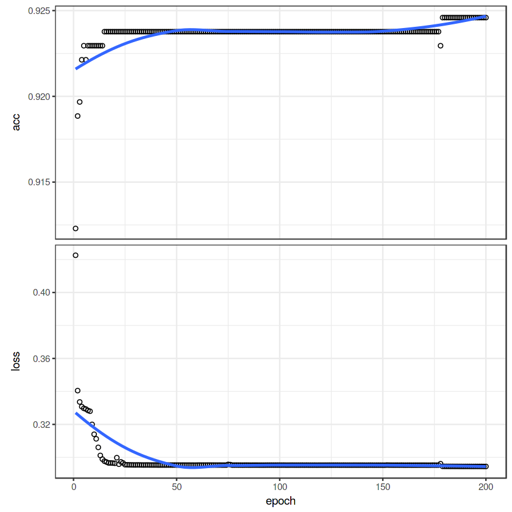

```r
tunedSimple  %$%
    history %>%
    plot()
```

#### Make Predictions

```r
tunedSimple %$%
    best_model %>%
    predict_classes(x_submit, batch_size = 128) -> classes.simple

data.frame(Id=Id,
          Predicted=classes.simple) -> submission.simple

submission.simple %>%
  mutate(Id = as.character(Id)) %>%
  write_csv("nn_submission_simple.csv")
```

### Simplified Neural Network with Balanced data (ROSE)

```r
tuneNeuralNetwork(model.simple,
                  train.rose,paramsGrid,
                  k=5) -> tunedSimpleRose
```

#### Test Score

```r
tunedSimpleRose %$%
    best_model %>%
    evaluate(x_test,
             y_test,
             batch_size = 128) -> score.simple.rose

score.simple.rose
```

**$loss**

1.16133909205126

**$acc**

0.896325461038454

#### Visualize Train Fit

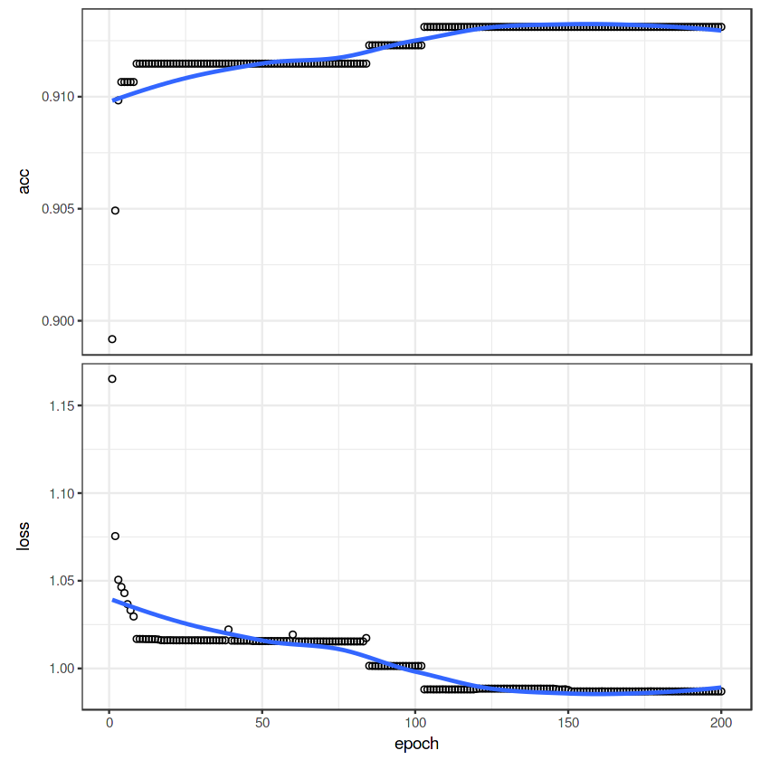

```r
tunedSimpleRose  %$%
    history %>%
    plot()
```

#### Make Predictions

```r
tunedSimpleRose %$%
    best_model %>%
    predict_classes(x_submit, batch_size = 128) -> classes.simple.rose

data.frame(Id=Id,
          Predicted=classes.simple.rose) -> submission.simple.rose

submission.simple.rose %>%
  mutate(Id = as.character(Id)) %>%
  write_csv("nn_submission_simple_rose.csv")
```

### Slightly more complex Neural Networn with unbalaced data

```r
tuneNeuralNetwork(model.complex,
                  train,paramsGrid,
                  k=5) -> tunedComplex
```

#### Test Score

```r
tunedComplex %$%
    best_model %>%
    evaluate(x_test,
             y_test,
             batch_size = 128) -> score.complex

score.complex
```

**$loss**

0.453967891408624

**$acc**

0.902230971285052

#### Visualize Train Fit

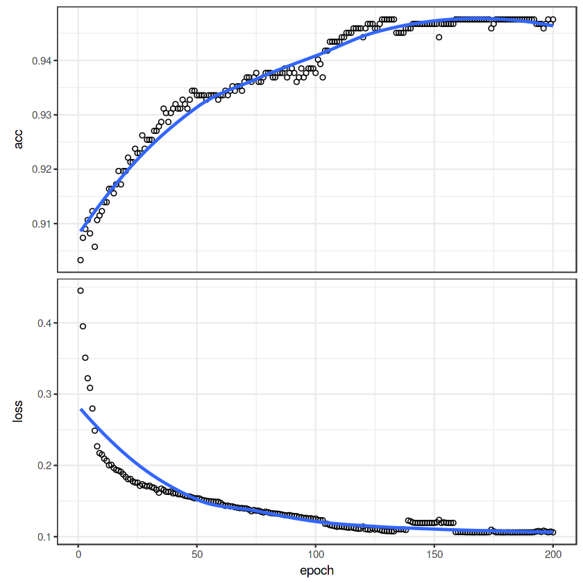

```r
tunedComplex  %$%
    history %>%
    plot()
```

#### Make Predictions

```r
tunedComplex %$%
    best_model %>%
    predict_classes(x_submit, batch_size = 128) -> classes.complex

data.frame(Id=Id,
          Predicted=classes.complex) -> submission.complex

submission.complex %>%
  mutate(Id = as.character(Id)) %>%
  write_csv("nn_submission_complex.csv")
```

### Slightly more complex Neural Networn with balaced data (ROSE)

```r
tuneNeuralNetwork(model.complex,
                  train.rose,paramsGrid,
                  k=5) -> tunedComplexRose
```

#### Test Score

```r
tunedComplexRose %$%
    best_model %>%
    evaluate(x_test,
             y_test,
             batch_size = 128) -> score.complex.rose

score.complex.rose
```

**$loss**

1.12783700325514

**$acc**

0.889107611704999

#### Visualize Train Fit

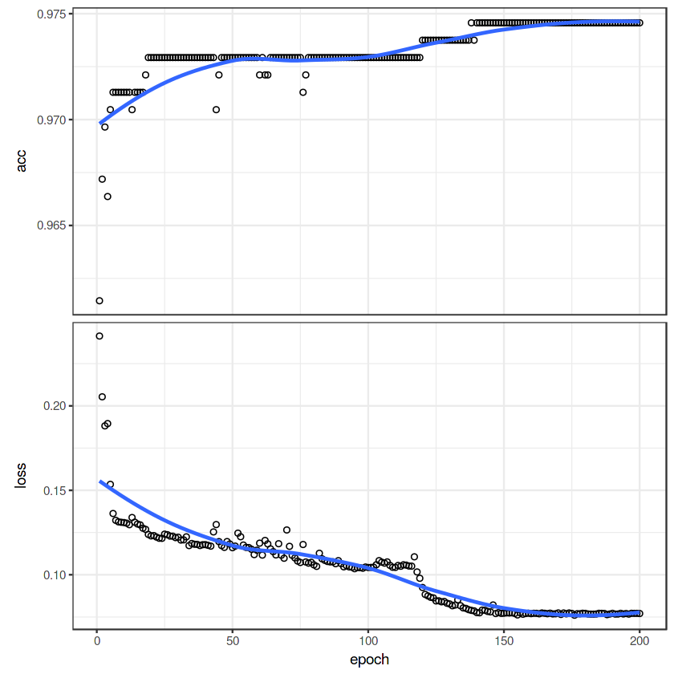

```r
tunedComplexRose  %$%
    history %>%
    plot()
```

#### Make Predictions

```r
tunedComplexRose %$%
    best_model %>%
    predict_classes(x_submit, batch_size = 128) -> classes.complex.rose

data.frame(Id=Id,
          Predicted=classes.complex.rose) -> submission.complex.rose

submission.complex.rose %>%
  mutate(Id = as.character(Id)) %>%
  write_csv("nn_submission_complex_rose.csv")
```